# Homework 3

##CHALLENGE 2: When we initially discussed the central limit theorem and confidence intervals, we showed how we could use bootstrapping to estimate standard errors and confidence intervals around certain parameter values, like the mean. Using bootstrapping, we can also do the same for estimating standard errors and CIs around regression parameters, such as β coefficients.

Using the “KamilarAndCooperData.csv” dataset, run a linear regression looking at log(MeanGroupSize) in relation to log(Body_mass_female_mean) and report your β coeffiecients (slope and intercept).

```r
# calculate log
d2 <- kc %>%
  mutate(logMGS = log(MeanGroupSize), logBMFM = log(Body_mass_female_mean)) %>%
  select(logMGS, logBMFM) %>%
  na.omit(kc)

# linear model
model_c2 <- lm(logMGS ~ logBMFM, data=d2)

# beta coefficients
coef(model_c2)
```

```
(Intercept)     logBMFM
 -1.7772580   0.5062813
```

*The beta coefficients are -1.78 for the intercept and 0.506 for log of mean female body mass.*

Then, use bootstrapping to sample from the dataset 1000 times with replacement, each time fitting the same model and calculating the appropriate coefficients. [The size of each sample should be equivalent to the total number of observations in the dataset.] This generates a bootstrap sampling distribution for each β coefficient. Plot a histogram of these sampling distributions for β0 and β1.

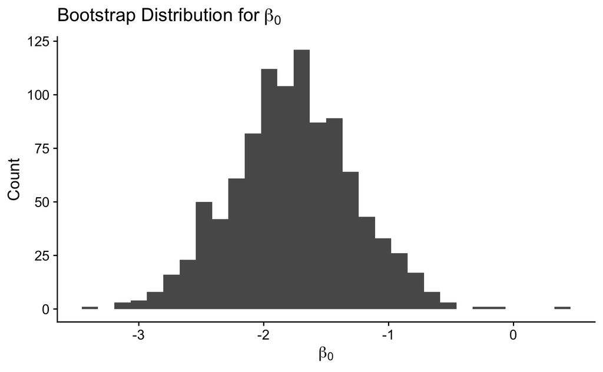

```r
set.seed(245234)
b0 <- vector(length = 1000)
b1 <- vector(length = 1000)
for (i in 1:1000) {

  slice <- d2 %>%
    slice_sample(n = nrow(d2), replace = TRUE)

  lm <- lm(logMGS ~ logBMFM, data=slice)

  b0[i] <- coef(lm)[[1]]
  b1[i] <- coef(lm)[[2]]

}

ggplot() +
  aes(b0) +
  geom_histogram() +
  theme_half_open() +
  ggtitle(expression("Bootstrap Distribution for" ~ beta[0])) +
  xlab(expression(beta[0])) +
  ylab("Count")
```

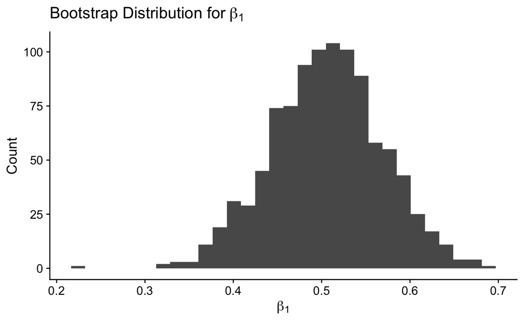

```r
ggplot() +
  aes(b1) +
  geom_histogram() +
  theme_half_open() +
  ggtitle(expression("Bootstrap Distribution for" ~ beta[1])) +
  xlab(expression(beta[1])) +
  ylab("Count")
```

Estimate the standard error for each of your β coefficients as the standard deviation of the sampling distribution from your bootstrap.

```r
print(paste("Standard error for β0:", round(sd(b0), 3)))
```

```
[1] "Standard error for β0: 0.488"
```

```r
print(paste("Standard error for β1:", round(sd(b1), 3)))
```

```
[1] "Standard error for β1: 0.063"
```

Also determine the 95% CI for each of your β coefficients based on the appropriate quantiles from your sampling distribution.

```r
print(paste0(
  "95% CI for β0: [", round(quantile(b0, 0.025), 3), ", ", round(quantile(b0, 0.975), 3), "]"
))
```

```
[1] "95% CI for β0: [-2.723, -0.821]"
```

```r
print(paste0(
  "95% CI for β1: [", round(quantile(b1, 0.025), 3), ", ", round(quantile(b1, 0.975), 3), "]"
))
```

```
[1] "95% CI for β1: [0.385, 0.628]"
```

How do the SEs estimated from the bootstrap sampling distribution compare to those estimated mathematically as part of lm() function?

```r
tidy(model_c2)$std.error
```

```
[1] 0.43751572 0.05562507
```

*The SEs estimated from the bootstrap are slightly higher.*

How do your bootstrap CIs compare to those estimated mathematically as part of the lm() function?

```r
confint(model_c2, level = .95)
```

```
                 2.5 %     97.5 %
(Intercept) -2.6422501 -0.9122659
logBMFM      0.3963075  0.6162550
```

*The confidence intervals for both estimates are wider for the bootstrap estimate than the lm() function.*